# exploring visa, party, int student data

seohyeongjeong

*Source file* ⇒ visa_data.Rmd

1. data cleaning (someone who can make loop, help me out)

```r
`1997` <- read.csv(file="/Users/seohyeongjeong/Desktop/visa/1997.csv", header=TRUE, sep=",") %>% select(Fiscal.Year.1997,F.1, J.1, M.1, Total.Visas) %>% mutate(Continent=Fiscal.Year.1997) %>% mutate(Year=1997)

`1997`$Continent[2:54] <- "Africa"
`1997`$Continent[58:96] <- "Asia"
`1997`$Continent[100:152] <- "Europe"
`1997`$Continent[156:177] <- "North America"
`1997`$Continent[181:194] <- "Oceania"
`1997`$Continent[198:217] <- "South America"

`1997` <- `1997`[-c(1, 55, 56, 57, 97, 98, 99, 153, 154, 155, 178, 179, 180, 195, 196, 197, 210:217), ]

names(`1997`)[names(`1997`) == 'Fiscal.Year.1997'] <- 'Country'
```

```r
`1998` <- read.csv(file="/Users/seohyeongjeong/Desktop/visa/1998.csv", header=TRUE, sep=",") %>% select(Fiscal.Year.1998,F.1, J.1, M.1, Total.Visas) %>% mutate(Continent=Fiscal.Year.1998) %>% mutate(Year=1998)

`1998`$Continent[2:54] <- "Africa"
`1998`$Continent[58:96] <- "Asia"
`1998`$Continent[100:152] <- "Europe"
`1998`$Continent[156:177] <- "North America"
`1998`$Continent[181:194] <- "Oceania"
`1998`$Continent[198:209] <- "South America"

`1998` <- `1998`[-c(1, 55, 56, 57, 97, 98, 99, 153, 154, 155, 178, 179, 180, 195, 196, 197, 210:217), ]

names(`1998`)[names(`1998`) == 'Fiscal.Year.1998'] <- 'Country'
```

```r
`1999` <- read.csv(file="/Users/seohyeongjeong/Desktop/visa/1999.csv", header=TRUE, sep=",") %>% select(Fiscal.Year.1999,F.1, J.1, M.1, Total.Visas) %>% mutate(Continent=Fiscal.Year.1999) %>% mutate(Year=1999)

`1999`$Continent[2:54] <- "Africa"
`1999`$Continent[58:96] <- "Asia"
`1999`$Continent[100:152] <- "Europe"
`1999`$Continent[156:177] <- "North America"
`1999`$Continent[181:194] <- "Oceania"
`1999`$Continent[198:209] <- "South America"

`1999` <- `1999`[-c(1, 55, 56, 57, 97, 98, 99, 153, 154, 155, 178, 179, 180, 195, 196, 197, 210:218), ]

names(`1999`)[names(`1999`) == 'Fiscal.Year.1999'] <- 'Country'
```

```r
`2000` <- read.csv(file="/Users/seohyeongjeong/Desktop/visa/2000.csv", header=TRUE, sep=",") %>% select(Fiscal.Year.2000,F.1, J.1, M.1, Total.Visas) %>% mutate(Continent=Fiscal.Year.2000) %>% mutate(Year=2000)

`2000`$Continent[2:54] <- "Africa"
`2000`$Continent[58:98] <- "Asia"
`2000`$Continent[102:154] <- "Europe"
`2000`$Continent[158:179] <- "North America"
`2000`$Continent[183:196] <- "Oceania"
`2000`$Continent[200:211] <- "South America"

`2000` <- `2000`[-c(1, 55, 56, 57, 99, 100, 101, 156, 155, 157, 181, 180, 182, 197, 198, 199, 212:219), ]

names(`2000`)[names(`2000`) == 'Fiscal.Year.2000'] <- 'Country'
```

```r
`2001` <- read.csv(file="/Users/seohyeongjeong/Desktop/visa/2001.csv", header=TRUE, sep=",") %>% select(Fiscal.Year.2001,F.1, J.1, M.1, Total.Visas) %>% mutate(Continent=Fiscal.Year.2001) %>% mutate(Year=2001)

`2001`$Continent[2:54] <- "Africa"
`2001`$Continent[58:98] <- "Asia"
`2001`$Continent[102:154] <- "Europe"
`2001`$Continent[158:179] <- "North America"
`2001`$Continent[183:196] <- "Oceania"
`2001`$Continent[200:211] <- "South America"

`2001` <- `2001`[-c(1, 55, 56, 57, 99, 100, 101, 156, 155, 157, 181, 180, 182, 197, 198, 199, 212:219), ]

names(`2001`)[names(`2001`) == 'Fiscal.Year.2001'] <- 'Country'
```

```r
`2002` <- read.csv(file="/Users/seohyeongjeong/Desktop/visa/2002.csv", header=TRUE, sep=",") %>% select(Fiscal.Year.2002,F.1, J.1, M.1, Total.Visas) %>% mutate(Continent=Fiscal.Year.2002) %>% mutate(Year=2002)

`2002`$Continent[2:54] <- "Africa"
`2002`$Continent[58:98] <- "Asia"
`2002`$Continent[102:154] <- "Europe"
`2002`$Continent[158:179] <- "North America"
`2002`$Continent[183:196] <- "Oceania"
`2002`$Continent[200:211] <- "South America"

`2002` <- `2002`[-c(1, 55, 56, 57, 99, 100, 101, 156, 155, 157, 181, 180, 182, 197, 198, 199, 212:219), ]

names(`2002`)[names(`2002`) == 'Fiscal.Year.2002'] <- 'Country'
```

```r
`2003` <- read.csv(file="/Users/seohyeongjeong/Desktop/visa/2003.csv", header=TRUE, sep=",") %>% select(Fiscal.Year.2003,F.1, J.1, M.1, Total.Visas) %>% mutate(Continent=Fiscal.Year.2003) %>% mutate(Year=2003)

`2003`$Continent[2:54] <- "Africa"
`2003`$Continent[58:98] <- "Asia"
`2003`$Continent[102:154] <- "Europe"
`2003`$Continent[158:179] <- "North America"
`2003`$Continent[183:196] <- "Oceania"
`2003`$Continent[200:211] <- "South America"

`2003` <- `2003`[-c(1, 55, 56, 57, 99, 100, 101, 156, 155, 157, 181, 180, 182, 197, 198, 199, 212:219), ]

names(`2003`)[names(`2003`) == 'Fiscal.Year.2003'] <- 'Country'
```

```r
`2004` <- read.csv(file="/Users/seohyeongjeong/Desktop/visa/2004.csv", header=TRUE, sep=",") %>% select(Fiscal.Year.2004,F.1, J.1, M.1, Total.Visas) %>% mutate(Continent=Fiscal.Year.2004) %>% mutate(Year=2004)

`2004`$Continent[2:54] <- "Africa"
`2004`$Continent[58:98] <- "Asia"
`2004`$Continent[102:154] <- "Europe"
`2004`$Continent[158:179] <- "North America"
`2004`$Continent[183:196] <- "Oceania"
`2004`$Continent[200:211] <- "South America"

`2004` <- `2004`[-c(1, 55, 56, 57, 99, 100, 101, 156, 155, 157, 181, 180, 182, 197, 198, 199, 212:219), ]

names(`2004`)[names(`2004`) == 'Fiscal.Year.2004'] <- 'Country'
```

```r
`2005` <- read.csv(file="/Users/seohyeongjeong/Desktop/visa/2005.csv", header=TRUE, sep=",") %>% select(Fiscal.Year.2005,F.1, J.1, M.1, Total.Visas) %>% mutate(Continent=Fiscal.Year.2005) %>% mutate(Year=2005)

`2005`$Continent[2:54] <- "Africa"
`2005`$Continent[58:98] <- "Asia"
`2005`$Continent[102:154] <- "Europe"
`2005`$Continent[158:179] <- "North America"
`2005`$Continent[183:196] <- "Oceania"
`2005`$Continent[200:211] <- "South America"

`2005` <- `2005`[-c(1, 55, 56, 57, 99, 100, 101, 156, 155, 157, 181, 180, 182, 197, 198, 199, 212:219), ]

names(`2005`)[names(`2005`) == 'Fiscal.Year.2005'] <- 'Country'
```

```r
`2006` <- read.csv(file="/Users/seohyeongjeong/Desktop/visa/2006.csv", header=TRUE, sep=",") %>% select(Fiscal.Year.2006,F.1, J.1, M.1, Total.Visas) %>% mutate(Continent=Fiscal.Year.2006) %>% mutate(Year=2006)

`2006`$Continent[2:54] <- "Africa"
`2006`$Continent[58:98] <- "Asia"
`2006`$Continent[102:155] <- "Europe"
`2006`$Continent[159:180] <- "North America"
`2006`$Continent[184:197] <- "Oceania"
`2006`$Continent[201:212] <- "South America"

`2006` <- `2006`[-c(1, 55, 56, 57, 99, 100, 101, 156, 157, 158, 181, 182, 183, 198, 199, 200, 213:244), ]

names(`2006`)[names(`2006`) == 'Fiscal.Year.2006'] <- 'Country'
```

```r
`2007` <- read.csv(file="/Users/seohyeongjeong/Desktop/visa/2007.csv", header=TRUE, sep=",") %>% select(Fiscal.Year.2007,F.1, J.1, M.1, Total.Visas) %>% mutate(Continent=Fiscal.Year.2007) %>% mutate(Year=2007)

`2007`$Continent[2:54] <- "Africa"
`2007`$Continent[59:99] <- "Asia"
`2007`$Continent[104:156] <- "Europe"
`2007`$Continent[161:182] <- "North America"
`2007`$Continent[187:200] <- "Oceania"
`2007`$Continent[205:216] <- "South America"

`2007` <- `2007`[-c(1, 55, 56, 57, 58, 100, 101, 102, 103, 157:160, 183:186, 201:204, 217:244), ]

names(`2007`)[names(`2007`) == 'Fiscal.Year.2007'] <- 'Country'
```

```r
`2008` <- read.csv(file="/Users/seohyeongjeong/Desktop/visa/2008.csv", header=TRUE, sep=",") %>% select(Fiscal.Year.2008,F.1, J.1, M.1, Total.Visas) %>% mutate(Continent=Fiscal.Year.2008) %>% mutate(Year=2008)

`2008`$Continent[2:54] <- "Africa"
`2008`$Continent[59:99] <- "Asia"
`2008`$Continent[104:159] <- "Europe"
`2008`$Continent[164:185] <- "North America"
`2008`$Continent[190:203] <- "Oceania"
`2008`$Continent[208:219] <- "South America"

`2008` <- `2008`[-c(1, 55:58,  100:103, 160:163, 186:189, 204:207, 220:244), ]

names(`2008`)[names(`2008`) == 'Fiscal.Year.2008'] <- 'Country'
```

```r
`2009` <- read.csv(file="/Users/seohyeongjeong/Desktop/visa/2009.csv", header=TRUE, sep=",") %>% select(Fiscal.Year.2009,F.1, J.1, M.1, Total.Visas) %>% mutate(Continent=Fiscal.Year.2009) %>% mutate(Year=2009)

`2009`$Continent[2:54] <- "Africa"
`2009`$Continent[59:99] <- "Asia"
`2009`$Continent[104:159] <- "Europe"
`2009`$Continent[164:185] <- "North America"
`2009`$Continent[190:203] <- "Oceania"
`2009`$Continent[208:219] <- "South America"

`2009` <- `2009`[-c(1, 55:58,  100:103, 160:163, 186:189, 204:207, 220:244), ]

names(`2009`)[names(`2009`) == 'Fiscal.Year.2009'] <- 'Country'
```

```r
`2010` <- read.csv(file="/Users/seohyeongjeong/Desktop/visa/2010.csv", header=TRUE, sep=",") %>% select(Fiscal.Year.2010,F.1, J.1, M.1, Total.Visas) %>% mutate(Continent=Fiscal.Year.2010) %>% mutate(Year=2010)

`2010`$Continent[2:54] <- "Africa"
`2010`$Continent[59:99] <- "Asia"
`2010`$Continent[104:159] <- "Europe"
`2010`$Continent[164:185] <- "North America"
`2010`$Continent[190:203] <- "Oceania"
`2010`$Continent[208:219] <- "South America"

`2010` <- `2010`[-c(1, 55:58,  100:103, 160:163, 186:189, 204:207, 220:244), ]

names(`2010`)[names(`2010`) == 'Fiscal.Year.2010'] <- 'Country'
```

```r
`2011` <- read.csv(file="/Users/seohyeongjeong/Desktop/visa/2011.csv", header=TRUE, sep=",") %>% select(Fiscal.Year.2011,F.1, J.1, M.1, Total.Visas) %>% mutate(Continent=Fiscal.Year.2011) %>% mutate(Year=2011)

`2011`$Continent[2:54] <- "Africa"
`2011`$Continent[59:99] <- "Asia"
`2011`$Continent[104:159] <- "Europe"
`2011`$Continent[164:185] <- "North America"
`2011`$Continent[190:203] <- "Oceania"
`2011`$Continent[208:219] <- "South America"

`2011` <- `2011`[-c(1, 55:58,  100:103, 160:163, 186:189, 204:207, 220:244), ]

names(`2011`)[names(`2011`) == 'Fiscal.Year.2011'] <- 'Country'
```

```r
`2012` <- read.csv(file="/Users/seohyeongjeong/Desktop/visa/2012.csv", header=TRUE, sep=",") %>% select(Fiscal.Year.2012,F.1, J.1, M.1, Total.Visas) %>% mutate(Continent=Fiscal.Year.2012) %>% mutate(Year=2012)

`2012`$Continent[2:55] <- "Africa"
`2012`$Continent[60:100] <- "Asia"
`2012`$Continent[105:160] <- "Europe"
`2012`$Continent[165:186] <- "North America"
`2012`$Continent[191:204] <- "Oceania"
`2012`$Continent[209:220] <- "South America"

`2012` <- `2012`[-c(1, 56:59,  101:104, 161:164, 187:190, 205:208, 221:244), ]

names(`2012`)[names(`2012`) == 'Fiscal.Year.2012'] <- 'Country'
```

```r
`2013` <- read.csv(file="/Users/seohyeongjeong/Desktop/visa/2013.csv", header=TRUE, sep=",") %>% select(Fiscal.Year.2013,F.1, J.1, M.1, Total.Visas) %>% mutate(Continent=Fiscal.Year.2013) %>% mutate(Year=2013)

`2013`$Continent[2:55] <- "Africa"
`2013`$Continent[60:100] <- "Asia"
`2013`$Continent[105:159] <- "Europe"
`2013`$Continent[164:185] <- "North America"
`2013`$Continent[190:203] <- "Oceania"
`2013`$Continent[208:219] <- "South America"

`2013` <- `2013`[-c(1, 56:59,  101:104, 160:163, 186:189, 204:207, 220:243), ]

names(`2013`)[names(`2013`) == 'Fiscal.Year.2013'] <- 'Country'
```

```r
`2014` <- read.csv(file="/Users/seohyeongjeong/Desktop/visa/2014.csv", header=TRUE, sep=",") %>% select(Fiscal.Year.2014,F.1, J.1, M.1, Total.Visas) %>% mutate(Continent=Fiscal.Year.2014) %>% mutate(Year=2014)

`2014`$Continent[2:55] <- "Africa"
`2014`$Continent[60:100] <- "Asia"
`2014`$Continent[105:159] <- "Europe"
`2014`$Continent[164:185] <- "North America"
`2014`$Continent[190:203] <- "Oceania"
`2014`$Continent[208:219] <- "South America"

`2014` <- `2014`[-c(1, 56:59,  101:104, 160:163, 186:189, 204:207, 220:243), ]

names(`2014`)[names(`2014`) == 'Fiscal.Year.2014'] <- 'Country'
```

```r
`2015` <- read.csv(file="/Users/seohyeongjeong/Desktop/visa/2015.csv", header=TRUE, sep=",") %>% select(Fiscal.Year.2015,F.1, J.1, M.1, Total.Visas) %>% mutate(Continent=Fiscal.Year.2015) %>% mutate(Year=2015)

`2015`$Continent[2:55] <- "Africa"
`2015`$Continent[60:100] <- "Asia"
`2015`$Continent[105:159] <- "Europe"
`2015`$Continent[164:185] <- "North America"
`2015`$Continent[190:203] <- "Oceania"
`2015`$Continent[208:219] <- "South America"

`2015` <- `2015`[-c(1, 56:59,  101:104, 160:163, 186:189, 204:207, 220:243), ]

names(`2015`)[names(`2015`) == 'Fiscal.Year.2015'] <- 'Country'
```

```r
`2016` <- read.csv(file="/Users/seohyeongjeong/Desktop/visa/2016.csv", header=TRUE, sep=",") %>% select(Fiscal.Year.2016,F.1, J.1, M.1, Total.Visas) %>% mutate(Continent=Fiscal.Year.2016) %>% mutate(Year=2016)

`2016`$Continent[2:55] <- "Africa"
`2016`$Continent[60:100] <- "Asia"
`2016`$Continent[105:159] <- "Europe"
`2016`$Continent[164:185] <- "North America"
`2016`$Continent[190:203] <- "Oceania"
`2016`$Continent[208:219] <- "South America"

`2016` <- `2016`[-c(1, 56:59,  101:104, 160:163, 186:189, 204:207, 220:243), ]

names(`2016`)[names(`2016`) == 'Fiscal.Year.2016'] <- 'Country'
```

visa_all data has country, F.1, J.1, M.1, Total.Visas, Continent, Year information

```r
visa_all <- rbind(`1997`, `1998`, `1999`, `2000`, `2001`, `2002`, `2003`, `2004`, `2005`, `2006`, `2007`, `2008`, `2009`, `2010`, `2011`, `2012`, `2013`, `2014`, `2015`, `2016`)

visa_all$F.1 <- as.numeric(visa_all$F.1)
visa_all$J.1 <- as.numeric(visa_all$J.1)
visa_all$M.1 <- as.numeric(visa_all$M.1)
visa_all$Total.Visas <- as.numeric((visa_all$Total.Visas))
visa_all$Year <- as.numeric(visa_all$Year)

write.csv(visa_all, '/Users/seohyeongjeong/Desktop/visa/visa_all.csv', row.names=FALSE)
```

2. plotting

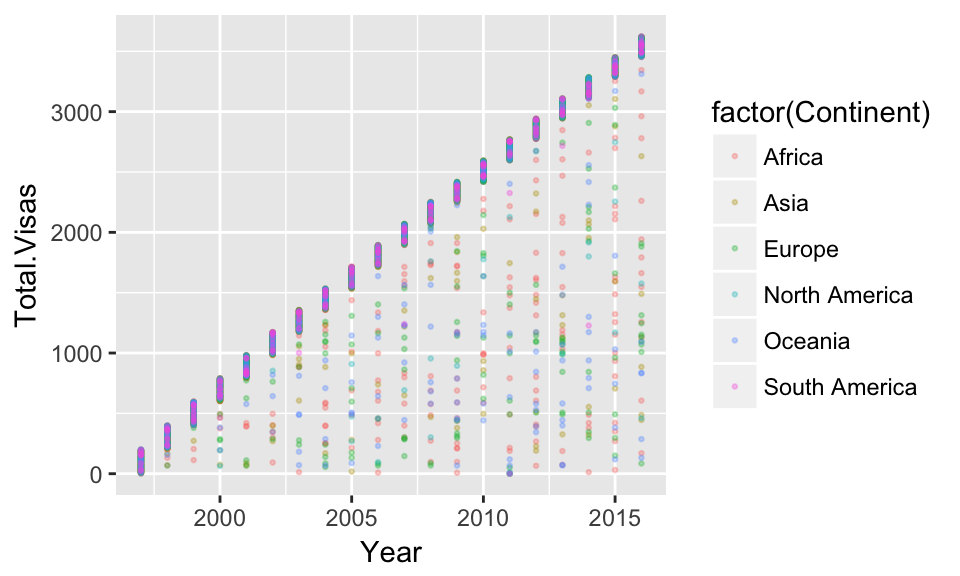

```r
visa_all %>% ggplot(aes(x=Year, y=Total.Visas)) + geom_point(size=0.5, alpha=0.3, aes(col=factor(Continent)))
```

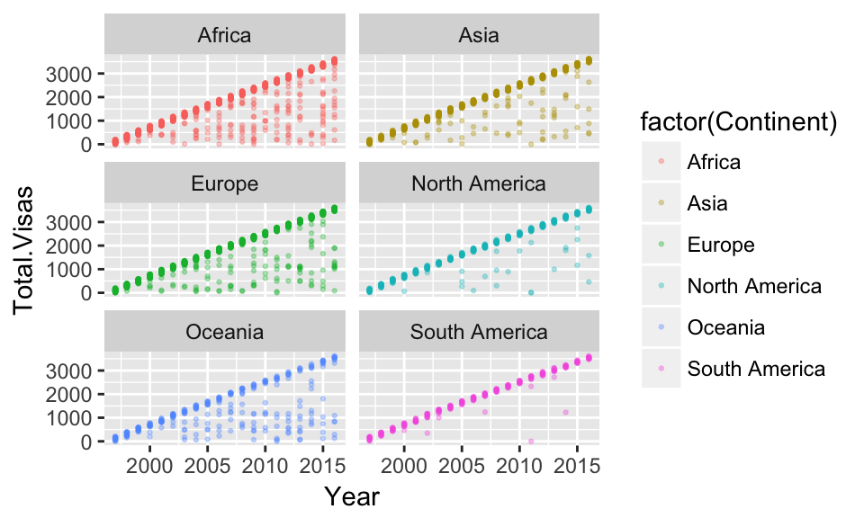

```r
visa_all %>% ggplot(aes(x=Year, y=Total.Visas)) + geom_point(aes(col=factor(Continent)), size=0.5, alpha=0.3) + facet_wrap( ~ Continent, ncol=2)
```

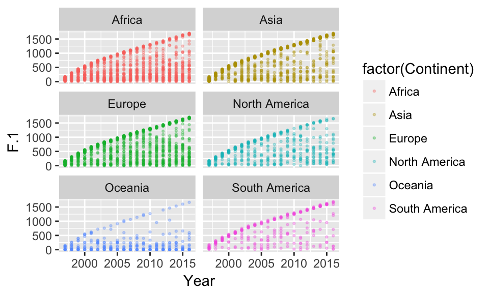

```r
visa_all %>% ggplot(aes(x=Year, y=F.1)) + geom_point(aes(col=factor(Continent)), size=0.5, alpha=0.3) + facet_wrap( ~ Continent, ncol=2)
```

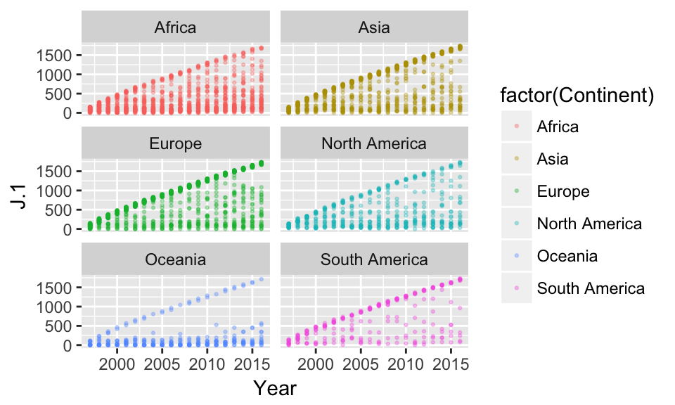

```r
visa_all %>% ggplot(aes(x=Year, y=J.1)) + geom_point(aes(col=factor(Continent)), size=0.5, alpha=0.3) + facet_wrap( ~ Continent, ncol=2)
```

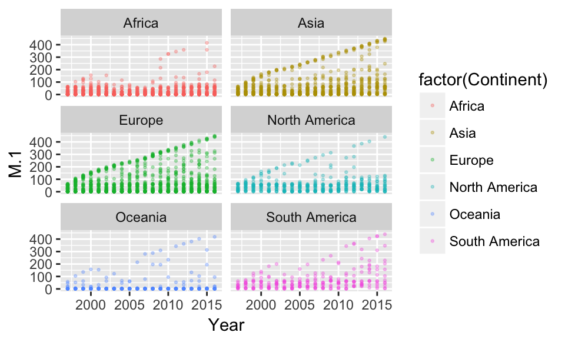

```r
visa_all %>% ggplot(aes(x=Year, y=M.1)) + geom_point(aes(col=factor(Continent)), size=0.5, alpha=0.3) + facet_wrap( ~ Continent, ncol=2)
```

3. adding more variables (president, congress information)

```r
CongressParty <- read.csv(file="/Users/seohyeongjeong/Desktop/Diversity-master/CongressParty/CongressParty.csv", header=TRUE, sep=",")

# creat a function that calculate the percentage of Denocrats in Senate and put the value below each year

senate <- CongressParty %>% filter(Chamber=="Senate") %>% select(-Chamber)
house <- CongressParty %>% filter(Chamber=="House") %>% select(-Chamber)

# %>% spread(key=Year, value=Seats) %>% select(-Chamber) %>% gather(key=Year, value=Seats, `1855`:`2017` )

# extract All and Democrat
senate_all <- senate %>% filter(PartyStatus=="All")
senate_Democrat <- senate %>% filter(PartyStatus=="Democrat")

house_all <- house %>% filter(PartyStatus=="All")
house_Democrat <- house %>% filter(PartyStatus=="Democrat")

percent=c()
for (i in 1:nrow(senate_Democrat)) {
  prop = senate_Democrat$Seats[i]/senate_all$Seats[i]
  percent <- c(percent, prop)
}

percent_house=c()
for (i in 1:nrow(house_Democrat)) {
  prop = house_Democrat$Seats[i]/house_all$Seats[i]
  percent_house <- c(percent_house, prop)
}
```

```r
senate_Democrat <- data.frame(senate_Democrat, percent)
names(senate_Democrat)[names(senate_Democrat) == 'percent'] <- 'percent_senate_democrat'

house_Democrat <- data.frame(house_Democrat, percent_house)
names(house_Democrat)[names(house_Democrat) == 'percent_house'] <- 'percent_house_democrat'
```

updating visa_all to visa_party. visa_party has visa information plus pary information

```r
Presidents <- read.csv(file="/Users/seohyeongjeong/Desktop/Diversity-master/Presidents/Presidents.csv", header=TRUE, sep=",") %>% select(Year, Party)

DominantCongressParty <- read.csv(file="/Users/seohyeongjeong/Desktop/Diversity-master/CongressParty/DominantCongressParty.csv", header=TRUE, sep=",")

visa_party <- visa_all %>% left_join(Presidents, by="Year", all.x=TRUE) %>% left_join(DominantCongressParty, by="Year", all.x=TRUE) %>% left_join(senate_Democrat, by="Year", all.x=TRUE) %>% select(-PartyStatus, -Seats) %>% left_join(house_Democrat, by="Year", all.x=TRUE) %>% select(-PartyStatus, -Seats) %>% mutate(f1_of_total=F.1/Total.Visas, j1_of_total=J.1/Total.Visas, m1_of_total=M.1/Total.Visas, prop_of_fjm=(F.1+J.1+M.1)/Total.Visas)

names(visa_party)[names(visa_party) == 'Party'] <- 'president'
names(visa_party)[names(visa_party) == 'House'] <- 'dominant_house'
names(visa_party)[names(visa_party) == 'Senate'] <- 'dominant_senate'


write.csv(visa_party, '/Users/seohyeongjeong/Desktop/visa/visa_party.csv', row.names=FALSE)
```

college enrollment data (not sure whether graduate students are included or not) https://www.statista.com/statistics/183995/us-college-enrollment-and-projections-in-public-and-private-institutions/

using college enrollment data find out the percentage of int students(indicated as # of visas) out of total college enrollment number

```r
USenrollment <- read.csv(file="/Users/seohyeongjeong/Desktop/number of college students.csv", header=TRUE, sep=",")

visa_party <- left_join(visa_party, USenrollment, by="Year", all.x=TRUE) %>% select(-Public, -Private)
```

4. another plotting(hard to make sense out of)

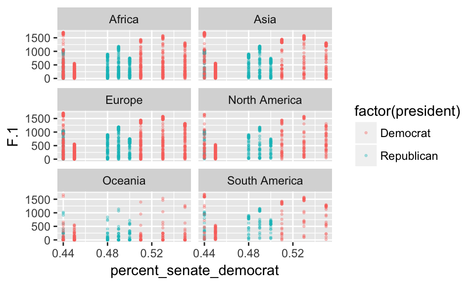

```r
visa_party %>% ggplot(aes(x=percent_senate_democrat, y=F.1)) + geom_point(aes(col=factor(president)), size=0.5, alpha=0.3) + facet_wrap( ~ Continent, ncol=2)
```

5. eliminationg country information to see data clearly (loop function needed)

```r
visa_1997 <- visa_party %>% filter(Year=="1997") %>% mutate(F.1=sum(F.1), J.1=sum(J.1), M.1=sum(M.1), Total.Visas=sum(Total.Visas))

visa_1998 <- visa_party %>% filter(Year=="1998") %>% mutate(F.1=sum(F.1), J.1=sum(J.1), M.1=sum(M.1), Total.Visas=sum(Total.Visas))

visa_1999 <- visa_party %>% filter(Year=="1999") %>% mutate(F.1=sum(F.1), J.1=sum(J.1), M.1=sum(M.1), Total.Visas=sum(Total.Visas))

visa_2000 <- visa_party %>% filter(Year=="2000") %>% mutate(F.1=sum(F.1), J.1=sum(J.1), M.1=sum(M.1), Total.Visas=sum(Total.Visas))

visa_2001 <- visa_party %>% filter(Year=="2001") %>% mutate(F.1=sum(F.1), J.1=sum(J.1), M.1=sum(M.1), Total.Visas=sum(Total.Visas))

visa_2002 <- visa_party %>% filter(Year=="2002") %>% mutate(F.1=sum(F.1), J.1=sum(J.1), M.1=sum(M.1), Total.Visas=sum(Total.Visas))

visa_2003 <- visa_party %>% filter(Year=="2003") %>% mutate(F.1=sum(F.1), J.1=sum(J.1), M.1=sum(M.1), Total.Visas=sum(Total.Visas))

visa_2004 <- visa_party %>% filter(Year=="2004") %>% mutate(F.1=sum(F.1), J.1=sum(J.1), M.1=sum(M.1), Total.Visas=sum(Total.Visas))

visa_2005 <- visa_party %>% filter(Year=="2005") %>% mutate(F.1=sum(F.1), J.1=sum(J.1), M.1=sum(M.1), Total.Visas=sum(Total.Visas))

visa_2006 <- visa_party %>% filter(Year=="2006") %>% mutate(F.1=sum(F.1), J.1=sum(J.1), M.1=sum(M.1), Total.Visas=sum(Total.Visas))

visa_2007 <- visa_party %>% filter(Year=="2007") %>% mutate(F.1=sum(F.1), J.1=sum(J.1), M.1=sum(M.1), Total.Visas=sum(Total.Visas))

visa_2008 <- visa_party %>% filter(Year=="2008") %>% mutate(F.1=sum(F.1), J.1=sum(J.1), M.1=sum(M.1), Total.Visas=sum(Total.Visas))

visa_2009 <- visa_party %>% filter(Year=="2009") %>% mutate(F.1=sum(F.1), J.1=sum(J.1), M.1=sum(M.1), Total.Visas=sum(Total.Visas))

visa_2010 <- visa_party %>% filter(Year=="2010") %>% mutate(F.1=sum(F.1), J.1=sum(J.1), M.1=sum(M.1), Total.Visas=sum(Total.Visas))

visa_2011 <- visa_party %>% filter(Year=="2011") %>% mutate(F.1=sum(F.1), J.1=sum(J.1), M.1=sum(M.1), Total.Visas=sum(Total.Visas))

visa_2012 <- visa_party %>% filter(Year=="2012") %>% mutate(F.1=sum(F.1), J.1=sum(J.1), M.1=sum(M.1), Total.Visas=sum(Total.Visas))

visa_2013 <- visa_party %>% filter(Year=="2013") %>% mutate(F.1=sum(F.1), J.1=sum(J.1), M.1=sum(M.1), Total.Visas=sum(Total.Visas))

visa_2014 <- visa_party %>% filter(Year=="2014") %>% mutate(F.1=sum(F.1), J.1=sum(J.1), M.1=sum(M.1), Total.Visas=sum(Total.Visas))

visa_2015 <- visa_party %>% filter(Year=="2015") %>% mutate(F.1=sum(F.1), J.1=sum(J.1), M.1=sum(M.1), Total.Visas=sum(Total.Visas))

visa_2016 <- visa_party %>% filter(Year=="2016") %>% mutate(F.1=sum(F.1), J.1=sum(J.1), M.1=sum(M.1), Total.Visas=sum(Total.Visas))

visa_summary <- rbind(visa_1997[1, ], visa_1998[1, ], visa_1999[1, ], visa_2000[1, ], visa_2001[1, ], visa_2002[1, ], visa_2003[1, ], visa_2004[1, ], visa_2005[1, ], visa_2006[1, ], visa_2007[1, ], visa_2008[1, ], visa_2009[1, ], visa_2010[1, ], visa_2011[1, ], visa_2012[1, ], visa_2013[1, ], visa_2014[1, ], visa_2015[1, ], visa_2016[1, ])

visa_summary <- visa_summary %>% select(-Country, -Continent) %>% mutate(`fjm/collegestudent`=(F.1+J.1+M.1)/(Total.in.millions.*1000000))
```

visa_summary has summary of visa_party data

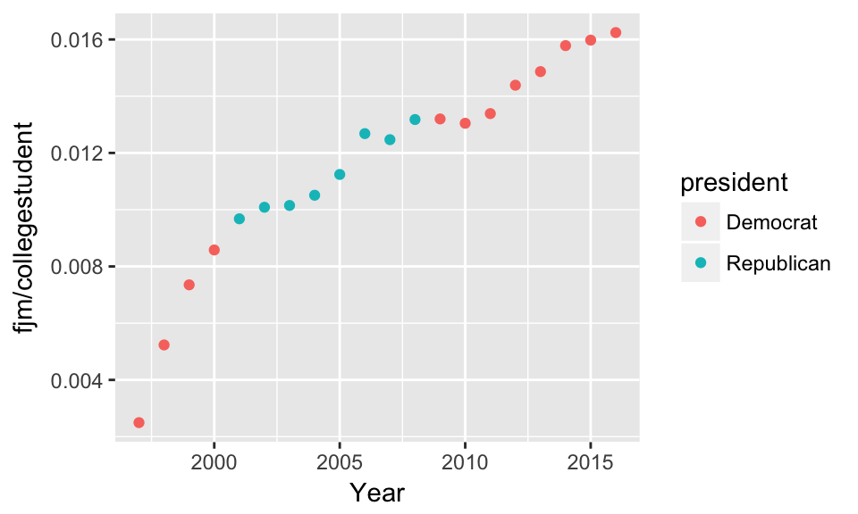

```r
visa_summary %>% ggplot(aes(x=Year, y=`fjm/collegestudent`)) + geom_point(aes(color=president))
```

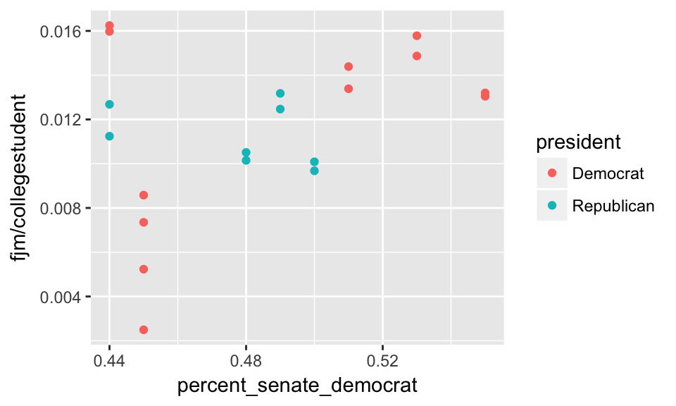

```r
visa_summary %>% ggplot(aes(x=percent_senate_democrat, y=`fjm/collegestudent`)) + geom_point(aes(color=president))
```

## not working code

for (i in 1997:2016){ visa_i <- visa_party %>% filter(Year==“i”) %>% mutate(F.1=sum(F.1), J.1=sum(J.1), M.1=sum(M.1), Total.Visas=sum(Total.Visas)) visa_i[1, ] }

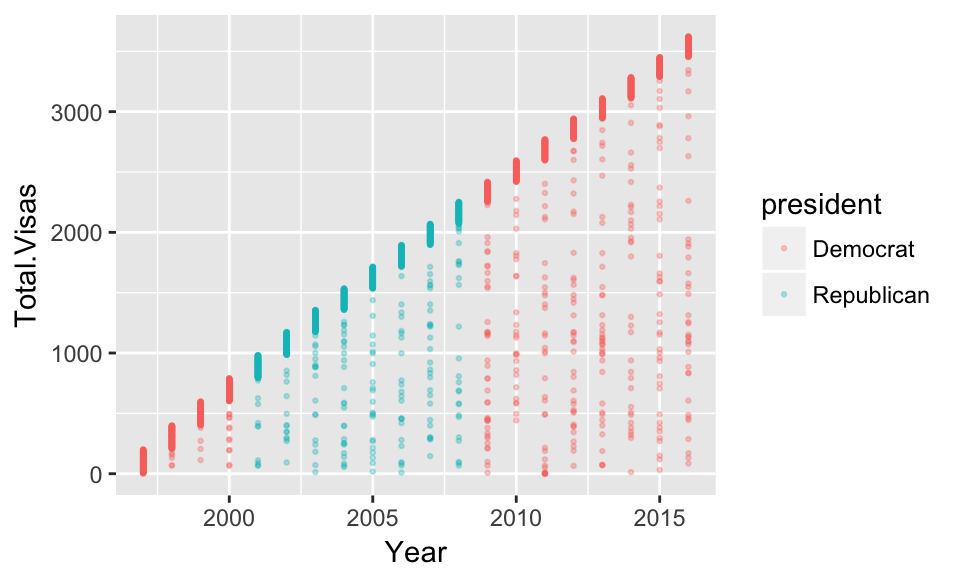

```r
visa_party %>% ggplot(aes(x=Year, y=Total.Visas)) + geom_point(aes(col=president), size=0.5, alpha=0.3)
```

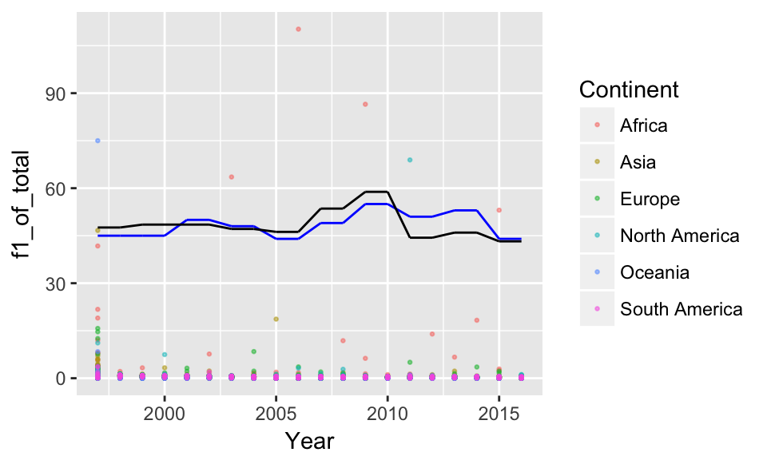

```r
visa_party %>% ggplot() + geom_point(aes(x=Year, y=f1_of_total, col=Continent), size=0.5, alpha=0.5) + geom_line(aes(x=Year, y=percent_senate_democrat*100), color="blue") + geom_line(aes(x=Year, y=percent_house_democrat*100))
```

```r
# I think we need pop data so that we can get the proportion
```

## not working code

mutate(Continent = ifelse(`1997`[2:54, ], “Africa”, ifelse(`1997`[58:96, ], “Asia”, ifelse(`1997`[100:152, ], “Europe”, ifelse(`1997`[156:177, ], “North America”, ifelse(`1997`[181:194, ], “Oceania”, ifelse(`1997`[198:209, ], “South America”, “”)))))))